# Homework #4

#### We will need to create a dictionary of team-name < = > to Metro area (across all sports):

#### Creating first df (NFL) for mapping

```python
#---    CREATING FOUR DFS, MAPPING A TEAM WITH A METRO AREA  ---
#     (THEN MERGE THEM, CONVERT TO A DICTIONARY, TO USE AS A MAPPER)
#   (YOU COULD ALSO KEEP THEM SEPARATE TO USE INDIVIDUALLY PER SPORT IF YOU WANTED)

# df.set_index('A').to_dict()['B']
#cities.Series(df.Letter.values,index=df.Position).to_dict()
#dict(zip(cities.NFL, cities.Metro))

t1 = cities[['NFL','METRO']].copy()

t1 = t1[t1.NFL != ''].reset_index(drop=True)

#  Note:  I have to break out metro areas that have multiple teams of the same sport !
t1 = t1.append({'NFL' : 'Giants' , 'METRO' : 'New York City'} , ignore_index=True)
t1 = t1.append({'NFL' : 'Jets' , 'METRO' : 'New York City'} , ignore_index=True)
t1 = t1.append({'NFL' : 'Rams' , 'METRO' : 'Los Angeles'} , ignore_index=True)
t1 = t1.append({'NFL' : 'Chargers' , 'METRO' : 'Los Angeles'} , ignore_index=True)
t1 = t1.append({'NFL' : '49ers' , 'METRO' : 'San Francisco Bay Area'} , ignore_index=True)
t1 = t1.append({'NFL' : 'Raiders' , 'METRO' : 'San Francisco Bay Area'} , ignore_index=True)
t1.METRO = t1.METRO.str.strip()#  clean whitespaces to be safe

t1 = t1[3:].reset_index(drop=True)  # THIS IS NOW A TRUE MAPPER FOR NFL TEAMS TO METRO AREAS

sh(t1.head(10))  # maps from the team name over to the METRO location...
#  Showing the first ten rows so you get the point.  We do this for each sport...
```

|  | NFL | METRO |
| --- | --- | --- |
| 0 | Bears | Chicago |
| 1 | Cowboys | Dallas–Fort Worth |
| 2 | Redskins | Washington, D.C. |
| 3 | Eagles | Philadelphia |
| 4 | Patriots | Boston |
| 5 | Vikings | Minneapolis–Saint Paul |
| 6 | Broncos | Denver |
| 7 | Dolphins | Miami–Fort Lauderdale |
| 8 | Cardinals | Phoenix |
| 9 | Lions | Detroit |

#### Creating second df (NBA) for mapping

```python
#  cities[['NBA','METRO']]
```

```python
t2 = cities[['NBA','METRO']].copy()

t2 = t2[t2.NBA != ''].reset_index(drop=True)

#  Breaking out multi-sport-teams
t2 = t2.append({'NBA' : 'Knicks' , 'METRO' : 'New York City'} , ignore_index=True)
t2 = t2.append({'NBA' : 'Nets' , 'METRO' : 'New York City'} , ignore_index=True)
t2 = t2.append({'NBA' : 'Lakers' , 'METRO' : 'Los Angeles'} , ignore_index=True)
t2 = t2.append({'NBA' : 'Clippers' , 'METRO' : 'Los Angeles'} , ignore_index=True)
t2.METRO = t2.METRO.str.strip()

t2 = t2[2:].reset_index(drop=True)
```

#### Creating third df (MLB) for mapping

```python
t3 = cities[['MLB','METRO']].copy()

t3 = t3[t3.MLB != ''].reset_index(drop=True)

t3 = t3.append({'MLB' : 'Yankees' , 'METRO' : 'New York City'} , ignore_index=True)
t3 = t3.append({'MLB' : 'Mets' , 'METRO' : 'New York City'} , ignore_index=True)
t3 = t3.append({'MLB' : 'Dodgers' , 'METRO' : 'Los Angeles'} , ignore_index=True)
t3 = t3.append({'MLB' : 'Angels' , 'METRO' : 'Los Angeles'} , ignore_index=True)
t3 = t3.append({'MLB' : 'Giants' , 'METRO' : 'San Francisco Bay Area'} , ignore_index=True)
t3 = t3.append({'MLB' : 'Athletics' , 'METRO' : 'San Francisco Bay Area'} , ignore_index=True)
t3 = t3.append({'MLB' : 'Cubs' , 'METRO' : 'Chicago'} , ignore_index=True)
t3 = t3.append({'MLB' : 'White Sox' , 'METRO' : 'Chicago'} , ignore_index=True)
t3.METRO = t3.METRO.str.strip()

t3 = t3[4:].reset_index(drop=True)  #  THIS IS NOW A TRUE MAPPER FOR MLB TEAMS TO METRO AREAS
```

#### Creating fourth df (NHL) for mapping

```python
t4 = cities[['NHL','METRO']].copy()

t4 = t4[t4.NHL != ''].reset_index(drop=True)  # remove rows with missing teams
t4 = t4[t4.NHL != 'Golden Knights'] # important to remove !

t4 = t4.append({'NHL' : 'Rangers' , 'METRO' : 'New York City'} , ignore_index=True)
t4 = t4.append({'NHL' : 'Islanders' , 'METRO' : 'New York City'} , ignore_index=True)
t4 = t4.append({'NHL' : 'Devils' , 'METRO' : 'New York City'} , ignore_index=True)
t4 = t4.append({'NHL' : 'Kings' , 'METRO' : 'Los Angeles'} , ignore_index=True)
t4 = t4.append({'NHL' : 'Ducks' , 'METRO' : 'Los Angeles'} , ignore_index=True)
t4.METRO = t4.METRO.str.strip()

t4 = t4[2:].reset_index(drop=True) #  THIS IS NOW A TRUE MAPPER FOR NHL TEAMS TO METRO AREAS
```

#### Now let's create a series of dictionaries to allow easy mapping

```python
#---  EACH OF THESE DICTIONARIES MAPS A SPORT TEAM TO ITS ASSOCIATED METRO AREA  ---
#     (I have specifically also made the `index` to be the sports team for clarity)
d1 = t1.set_index('NFL').to_dict()['METRO']
d2 = t2.set_index('NBA').to_dict()['METRO']
d3 = t3.set_index('MLB').to_dict()['METRO']
d4 = t4.set_index('NHL').to_dict()['METRO']
```

## So let's close the deal here:

### - NFL:

```python
#---  d1 is a previously created dictionary that maps nfl teams to the metro city  ---
#             (We will do this same approach for each sport)

print("Nicely created dictionary we will use to map the NFL team to the Metro Area: ")
sh(d1)
```

```
Nicely created dictionary we will use to map the NFL team to the Metro Area:
```

```
{'49ers': 'San Francisco Bay Area',
 'Bears': 'Chicago',
 'Bengals': 'Cincinnati',
 'Bills': 'Buffalo',
 'Broncos': 'Denver',
 'Browns': 'Cleveland',
 'Buccaneers': 'Tampa Bay Area',
 'Cardinals': 'Phoenix',
 'Chargers': 'Los Angeles',
 'Chiefs': 'Kansas City',
 'Colts': 'Indianapolis',
 'Cowboys': 'Dallas–Fort Worth',
 'Dolphins': 'Miami–Fort Lauderdale',
 'Eagles': 'Philadelphia',
 'Falcons': 'Atlanta',
 'Giants': 'New York City',
 'Jaguars': 'Jacksonville',
 'Jets': 'New York City',
 'Lions': 'Detroit',
 'Packers': 'Green Bay',
 'Panthers': 'Charlotte',
 'Patriots': 'Boston',
 'Raiders': 'San Francisco Bay Area',
 'Rams': 'Los Angeles',
 'Ravens': 'Baltimore',
 'Redskins': 'Washington, D.C.',
 'Saints': 'New Orleans',
 'Seahawks': 'Seattle',
 'Steelers': 'Pittsburgh',
 'Texans': 'Houston',
 'Titans': 'Nashville',
 'Vikings': 'Minneapolis–Saint Paul'}
```

```python
#---  f_nfl is the consolidated team and WIN_PCT for that nfl team
#---  Add nickname of the last word of the team  ---
nfl2 = f_nfl.copy()
nfl2['Nickname'] = f_nfl['team'].apply(lambda x: x.split()[-1]).copy()

#---  MAP THE TEAM NICKNAME TO THE METRO AREA IT IS ASSOCIATED WITH  ---
nfl2['MSO'] = nfl2['Nickname'].map(d1)

#---  Creating map link from metro area to master population  ---
metro_to_pop = cities.loc[:, ['METRO', 'POP']].copy()
#sh(metro_to_pop.head())

#---  Flip it to a dictionary to make it clean  ---
metro_to_pop_DB = metro_to_pop.set_index('METRO').to_dict()['POP']

#---  The Population value is now to be mapped appropriated (associated with correct METRO)
nfl2['Population'] = nfl2.MSO.map(metro_to_pop_DB)

#---  show first five rows of final nfl dataframe  ---
nfl2.sort_values('Population', ascending=False, inplace=True)#  Show based on descending population

#  For clarity, I'm going to show what our final NFL dataset looks like, and of course,
#  we will create four separate datasets, one for each sport...
nfl2.reset_index(inplace=True, drop=True)#  resetting index

display(HTML(nfl2.head(25).to_html(index=False)))   # i like pretty
```

| team | WIN_PCT | year | Nickname | MSO | Population |
| --- | --- | --- | --- | --- | --- |
| New York Jets | 0.6250 | 2015 | Jets | New York City | 20,153,634.0000 |
| New York Jets | 0.2500 | 2014 | Jets | New York City | 20,153,634.0000 |
| New York Giants | 0.1875 | 2017 | Giants | New York City | 20,153,634.0000 |
| New York Jets | 0.3125 | 2016 | Jets | New York City | 20,153,634.0000 |
| New York Giants | 0.3125 | 2018 | Giants | New York City | 20,153,634.0000 |
| New York Giants | 0.6875 | 2016 | Giants | New York City | 20,153,634.0000 |
| New York Giants | 0.3750 | 2015 | Giants | New York City | 20,153,634.0000 |
| New York Jets | 0.3125 | 2017 | Jets | New York City | 20,153,634.0000 |
| New York Jets | 0.2500 | 2018 | Jets | New York City | 20,153,634.0000 |
| New York Giants | 0.3750 | 2014 | Giants | New York City | 20,153,634.0000 |
| St. Louis Rams | 0.4375 | 2015 | Rams | Los Angeles | 13,310,447.0000 |
| Los Angeles Rams | 0.2500 | 2016 | Rams | Los Angeles | 13,310,447.0000 |
| Los Angeles Chargers | 0.5625 | 2017 | Chargers | Los Angeles | 13,310,447.0000 |
| Los Angeles Rams | 0.6875 | 2017 | Rams | Los Angeles | 13,310,447.0000 |
| San Diego Chargers | 0.3125 | 2016 | Chargers | Los Angeles | 13,310,447.0000 |
| Los Angeles Rams | 0.8125 | 2018 | Rams | Los Angeles | 13,310,447.0000 |
| Los Angeles Chargers | 0.7500 | 2018 | Chargers | Los Angeles | 13,310,447.0000 |
| San Diego Chargers | 0.2500 | 2015 | Chargers | Los Angeles | 13,310,447.0000 |
| San Diego Chargers | 0.5625 | 2014 | Chargers | Los Angeles | 13,310,447.0000 |
| St. Louis Rams | 0.3750 | 2014 | Rams | Los Angeles | 13,310,447.0000 |
| Chicago Bears | 0.1875 | 2016 | Bears | Chicago | 9,512,999.0000 |
| Chicago Bears | 0.3750 | 2015 | Bears | Chicago | 9,512,999.0000 |
| Chicago Bears | 0.7500 | 2018 | Bears | Chicago | 9,512,999.0000 |
| Chicago Bears | 0.3125 | 2017 | Bears | Chicago | 9,512,999.0000 |
| Chicago Bears | 0.3125 | 2014 | Bears | Chicago | 9,512,999.0000 |

#### Tricky: You will now consolidate all the years, by averaging the winning percentage across those five years

```python
print("The following contains the overall winning percentage (in descending order) over the course of five years, for all NFL teams:")
nfl_5 = nfl2

nfl_5_1 = nfl_5.groupby(['team','MSO','Population'], as_index=False).WIN_PCT.mean()

#.agg({'WIN_PCT':'mean'})
#nfl_5_1= nfl_5.groupby('team', as_index=False)#['WIN_PCT'].mean() #  .WIN_PCT.mean()
# nfl_5_1 = nfl_5_1.sort_values('WIN_PCT', ascending=False)
# nfl_5_1.reset_index(inplace=True, drop=True)
nfl_5_1 = nfl_5_1.sort_values('WIN_PCT', ascending=False)
#sh(nfl_5_1)
display(HTML(nfl_5_1.to_html(index=False)))
```

```
The following contains the overall winning percentage (in descending order) over the course of five years, for all NFL teams:
```

| team | MSO | Population | WIN_PCT |
| --- | --- | --- | --- |
| New England Patriots | Boston | 4,794,447.0000 | 0.7750 |
| Pittsburgh Steelers | Pittsburgh | 2,342,299.0000 | 0.6825 |
| Kansas City Chiefs | Kansas City | 2,104,509.0000 | 0.6750 |
| Los Angeles Chargers | Los Angeles | 13,310,447.0000 | 0.6562 |
| Seattle Seahawks | Seattle | 3,798,902.0000 | 0.6458 |
| Dallas Cowboys | Dallas–Fort Worth | 7,233,323.0000 | 0.6000 |
| Minnesota Vikings | Minneapolis–Saint Paul | 3,551,036.0000 | 0.5942 |
| Los Angeles Rams | Los Angeles | 13,310,447.0000 | 0.5833 |
| Carolina Panthers | Charlotte | 2,474,314.0000 | 0.5808 |
| Philadelphia Eagles | Philadelphia | 6,070,500.0000 | 0.5750 |
| Green Bay Packers | Green Bay | 318,236.0000 | 0.5675 |
| New Orleans Saints | New Orleans | 1,268,883.0000 | 0.5625 |
| Denver Broncos | Denver | 2,853,077.0000 | 0.5500 |
| Arizona Cardinals | Phoenix | 4,661,537.0000 | 0.5308 |
| Cincinnati Bengals | Cincinnati | 2,165,139.0000 | 0.5258 |
| Houston Texans | Houston | 6,772,470.0000 | 0.5250 |
| Atlanta Falcons | Atlanta | 5,789,700.0000 | 0.5250 |
| Detroit Lions | Detroit | 4,297,617.0000 | 0.5250 |
| Baltimore Ravens | Baltimore | 2,798,886.0000 | 0.5250 |
| Indianapolis Colts | Indianapolis | 2,004,230.0000 | 0.5125 |
| Buffalo Bills | Buffalo | 1,132,804.0000 | 0.4875 |
| Miami Dolphins | Miami–Fort Lauderdale | 6,066,387.0000 | 0.4625 |
| Washington Redskins | Washington, D.C. | 6,131,977.0000 | 0.4442 |
| St. Louis Rams | Los Angeles | 13,310,447.0000 | 0.4062 |
| Tennessee Titans | Nashville | 1,865,298.0000 | 0.4000 |
| Oakland Raiders | San Francisco Bay Area | 6,657,982.0000 | 0.4000 |
| Chicago Bears | Chicago | 9,512,999.0000 | 0.3875 |
| New York Giants | New York City | 20,153,634.0000 | 0.3875 |
| San Diego Chargers | Los Angeles | 13,310,447.0000 | 0.3750 |
| New York Jets | New York City | 20,153,634.0000 | 0.3500 |
| Tampa Bay Buccaneers | Tampa Bay Area | 3,032,171.0000 | 0.3375 |
| Jacksonville Jaguars | Jacksonville | 1,478,212.0000 | 0.3250 |
| San Francisco 49ers | San Francisco Bay Area | 6,657,982.0000 | 0.3125 |
| Cleveland Browns | Cleveland | 2,055,612.0000 | 0.2308 |

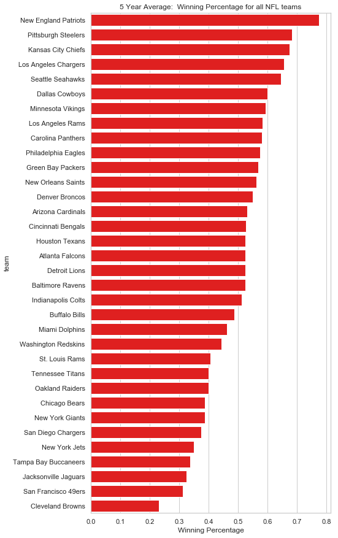

```python
#### Let's take a look at this graphed by WIN_PCT (across all teams)

sns.set(style="whitegrid")
plt.figure(figsize=(7,15))
ax = sns.barplot(x=nfl_5_1['WIN_PCT'], y=nfl_5_1['team'], color='red')
ax.set_title('5 Year Average:  Winning Percentage for all NFL teams')
ax.set_xlabel('Winning Percentage');
```

```python
#nfl_5_1 = nfl_5_1.sort_values('WIN_PCT', ascending=False)


def nfl_correlation():
    population_by_region = nfl_5_1.Population
    win_loss_by_region = nfl_5_1.WIN_PCT
    return stats.pearsonr(population_by_region, win_loss_by_region)

nfl_correlation()
```

```
(-0.2323916533549289, 0.18597799912713908)
```

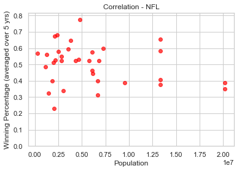

```python
#---  EXAMINING THE NFL DATA SCATTER PLOT  ---

x = nfl_5_1.Population
y = nfl_5_1.WIN_PCT
plt.scatter(x, y, c='red', alpha=.7)
plt.title("Correlation - NFL")
plt.xlabel("Population")
plt.ylabel("Winning Percentage (averaged over 5 yrs)")
#, s=area, c=colors, alpha=0.5)
#  plt.scatter(x, y, s=area, c=colors, alpha=0.5)
plt.ylim(0)
plt.show();
```

**Thoughts:** * Some negative correlation (-.23), so one couldn't really say for football that Population/Metro area made a different; more the opposite

### - NBA:

```python
#  d2 is the previously created dictionary to map NBA teams to Metro Areas
```

```python
#---  f_nba is the consolidated team and WIN_PCT for that nba team
#---  Add nickname of the last word of the team  ---
nba2 = f_nba.copy()
nba2['Nickname'] = f_nba['team'].apply(lambda x: x.split()[-1]).copy()
nba2.replace({'Blazers': 'Trail Blazers'}, inplace=True)

#---  MAP THE TEAM NICKNAME TO THE METRO AREA IT IS ASSOCIATED WITH  ---
nba2['MSO'] = nba2['Nickname'].map(d2)#  always make sure you are using the right dictionary !

#---  Creating map link from metro area to master population  ---
#  already exists from earlier:  metro_to_pop = cities.loc[:, ['METRO', 'POP']].copy()
#  already exists from earlier:  metro_to_pop_DB = metro_to_pop.set_index('METRO').to_dict()['POP']

#---  The Population value is now to be mapped appropriated (associated with correct METRO)
nba2['Population'] = nba2.MSO.map(metro_to_pop_DB)

#---  show first five rows of final nfl dataframe  ---
nba2.sort_values('Population', ascending=False, inplace=True)#  Show based on descending population
nba2.reset_index(inplace=True, drop=True)#  resetting index

display(HTML(nba2.head(25).to_html(index=False)))
# just to give you an idea of some of the rows
```

| team | WIN_PCT | year | Nickname | MSO | Population |
| --- | --- | --- | --- | --- | --- |
| Brooklyn Nets | 0.2439 | 2017 | Nets | New York City | 20,153,634.0000 |
| New York Knicks | 0.3537 | 2018 | Knicks | New York City | 20,153,634.0000 |
| Brooklyn Nets | 0.2561 | 2016 | Nets | New York City | 20,153,634.0000 |
| Brooklyn Nets | 0.5366 | 2014 | Nets | New York City | 20,153,634.0000 |
| New York Knicks | 0.4512 | 2014 | Knicks | New York City | 20,153,634.0000 |
| New York Knicks | 0.3902 | 2016 | Knicks | New York City | 20,153,634.0000 |
| New York Knicks | 0.2073 | 2015 | Knicks | New York City | 20,153,634.0000 |
| Brooklyn Nets | 0.3415 | 2018 | Nets | New York City | 20,153,634.0000 |
| Brooklyn Nets | 0.4634 | 2015 | Nets | New York City | 20,153,634.0000 |
| New York Knicks | 0.3780 | 2017 | Knicks | New York City | 20,153,634.0000 |
| Los Angeles Clippers | 0.6951 | 2014 | Clippers | Los Angeles | 13,310,447.0000 |
| Los Angeles Lakers | 0.2073 | 2016 | Lakers | Los Angeles | 13,310,447.0000 |
| Los Angeles Lakers | 0.4268 | 2018 | Lakers | Los Angeles | 13,310,447.0000 |
| Los Angeles Clippers | 0.5122 | 2018 | Clippers | Los Angeles | 13,310,447.0000 |
| Los Angeles Clippers | 0.6829 | 2015 | Clippers | Los Angeles | 13,310,447.0000 |
| Los Angeles Lakers | 0.3171 | 2017 | Lakers | Los Angeles | 13,310,447.0000 |
| Los Angeles Lakers | 0.2561 | 2015 | Lakers | Los Angeles | 13,310,447.0000 |
| Los Angeles Lakers | 0.3293 | 2014 | Lakers | Los Angeles | 13,310,447.0000 |
| Los Angeles Clippers | 0.6463 | 2016 | Clippers | Los Angeles | 13,310,447.0000 |
| Los Angeles Clippers | 0.6220 | 2017 | Clippers | Los Angeles | 13,310,447.0000 |
| Chicago Bulls | 0.5854 | 2014 | Bulls | Chicago | 9,512,999.0000 |
| Chicago Bulls | 0.5000 | 2017 | Bulls | Chicago | 9,512,999.0000 |
| Chicago Bulls | 0.6098 | 2015 | Bulls | Chicago | 9,512,999.0000 |
| Chicago Bulls | 0.3293 | 2018 | Bulls | Chicago | 9,512,999.0000 |
| Chicago Bulls | 0.5122 | 2016 | Bulls | Chicago | 9,512,999.0000 |

#### Tricky: You will now consolidate all the years, by averaging the winning percentage across those five years

```python
print("The following contains the overall winning percentage (in descending order) over the course of five years, for all NFL teams:")
nba_5 = nba2

nba_5_1 = nba_5.groupby(['team','MSO','Population'], as_index=False).WIN_PCT.mean()

#.agg({'WIN_PCT':'mean'})
#nfl_5_1= nfl_5.groupby('team', as_index=False)#['WIN_PCT'].mean() #  .WIN_PCT.mean()
# nfl_5_1 = nfl_5_1.sort_values('WIN_PCT', ascending=False)
# nfl_5_1.reset_index(inplace=True, drop=True)
nba_5_1 = nba_5_1.sort_values('WIN_PCT', ascending=False)
#sh(nfl_5_1)
display(HTML(nba_5_1.to_html(index=False)))
```

[output not shown]

| team | MSO | Population | WIN_PCT |
| --- | --- | --- | --- |
| Golden State Warriors | San Francisco Bay Area | 6,657,982.0000 | 0.7707 |
| San Antonio Spurs | San Antonio | 2,429,609.0000 | 0.7122 |
| Houston Rockets | Houston | 6,772,470.0000 | 0.6610 |
| Toronto Raptors | Toronto | 5,928,040.0000 | 0.6415 |
| Los Angeles Clippers | Los Angeles | 13,310,447.0000 | 0.6317 |
| Oklahoma City Thunder | Oklahoma City | 1,373,211.0000 | 0.6195 |
| Cleveland Cavaliers | Cleveland | 2,055,612.0000 | 0.5951 |
| Portland Trail Blazers | Portland | 2,424,955.0000 | 0.5829 |
| Indiana Pacers | Indianapolis | 2,004,230.0000 | 0.5585 |
| Miami Heat | Miami–Fort Lauderdale | 6,066,387.0000 | 0.5463 |
| Washington Wizards | Washington, D.C. | 6,131,977.0000 | 0.5439 |
| Boston Celtics | Boston | 4,794,447.0000 | 0.5390 |
| Atlanta Hawks | Atlanta | 5,789,700.0000 | 0.5195 |
| Memphis Grizzlies | Memphis | 1,342,842.0000 | 0.5171 |
| Chicago Bulls | Chicago | 9,512,999.0000 | 0.5073 |
| Utah Jazz | Salt Lake City | 1,186,187.0000 | 0.4927 |
| Dallas Mavericks | Dallas–Fort Worth | 7,233,323.0000 | 0.4829 |
| Charlotte Hornets | Charlotte | 2,474,314.0000 | 0.4665 |
| New Orleans Pelicans | New Orleans | 1,268,883.0000 | 0.4659 |
| Denver Nuggets | Denver | 2,853,077.0000 | 0.4512 |
| Detroit Pistons | Detroit | 4,297,617.0000 | 0.4415 |
| Milwaukee Bucks | Milwaukee | 1,572,482.0000 | 0.4268 |
| Minnesota Timberwolves | Minneapolis–Saint Paul | 3,551,036.0000 | 0.3976 |
| Phoenix Suns | Phoenix | 4,661,537.0000 | 0.3780 |
| Brooklyn Nets | New York City | 20,153,634.0000 | 0.3683 |
| Sacramento Kings | Sacramento | 2,296,418.0000 | 0.3634 |
| New York Knicks | New York City | 20,153,634.0000 | 0.3561 |
| Orlando Magic | Orlando | 2,441,257.0000 | 0.3341 |
| Philadelphia 76ers | Philadelphia | 6,070,500.0000 | 0.3098 |
| Los Angeles Lakers | Los Angeles | 13,310,447.0000 | 0.3073 |

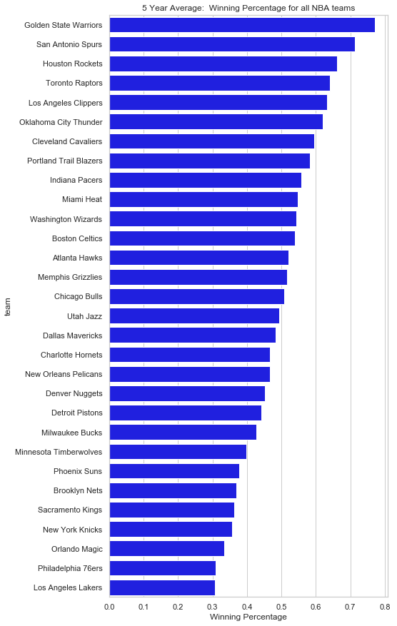

```python
#### Let's take a look at this graphed by WIN_PCT (across all teams)

sns.set(style="whitegrid")
plt.figure(figsize=(7,15))
ax = sns.barplot(x=nba_5_1['WIN_PCT'], y=nba_5_1['team'], color='blue')
ax.set_title('5 Year Average:  Winning Percentage for all NBA teams')
ax.set_xlabel('Winning Percentage');
```

- For the love of all holy what happened to my LA Lakers ???

```python
def nba_correlation():
    population_by_region = nba_5_1.Population
    win_loss_by_region = nba_5_1.WIN_PCT
    return stats.pearsonr(population_by_region, win_loss_by_region)

nba_correlation()
```

```
(-0.2266830583162794, 0.22835978860387182)
```

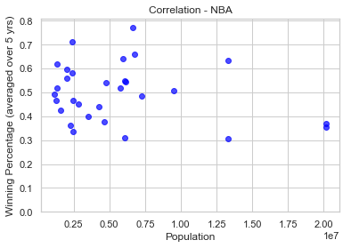

```python
#---  EXAMINING THE NBA DATA SCATTER PLOT  ---

x = nba_5_1.Population
y = nba_5_1.WIN_PCT
plt.scatter(x, y, c='blue', alpha=.7)
plt.title("Correlation - NBA")
plt.xlabel("Population")
plt.ylabel("Winning Percentage (averaged over 5 yrs)")
#, s=area, c=colors, alpha=0.5)
#  plt.scatter(x, y, s=area, c=colors, alpha=0.5)
plt.ylim(0)
plt.show();
```

### - MLB:

```python
#  d3 is the previously created dictionary to map NBA teams to Metro Areas
```

```python
#---  f_mlb is the consolidated team and WIN_PCT for that mlb team
mlb2 = f_mlb.copy()
mlb2['Nickname'] = f_mlb['team'].apply(lambda x: x.split()[-1]).copy()
mlb2.replace({'Jays': 'Blue Jays'}, inplace=True); mlb2.iloc[8,2] = 'White Sox'
mlb2.iloc[0,2] = 'Red Sox'

#---  MAP THE TEAM NICKNAME TO THE METRO AREA IT IS ASSOCIATED WITH  ---
mlb2['MSO'] = mlb2['Nickname'].map(d3)
#---  The Population value is now to be mapped appropriated (associated with correct METRO)
mlb2['Population'] = mlb2.MSO.map(metro_to_pop_DB)
#  sh(mlb2.sort_values('Population', ascending=False))
#  sh(mlb2)
mlb2.sort_values('Population', ascending=False, inplace=True)
mlb2.reset_index(inplace=True, drop=True)#

display(HTML(mlb2.head(25).to_html(index=False)))
```

| team | WIN_PCT | year | Nickname | MSO | Population |
| --- | --- | --- | --- | --- | --- |
| New York Yankees | 0.6173 | 2018 | Yankees | New York City | 20,153,634.0000 |
| New York Yankees | 0.5185 | 2014 | Yankees | New York City | 20,153,634.0000 |
| New York Yankees | 0.5185 | 2016 | Yankees | New York City | 20,153,634.0000 |
| New York Mets | 0.5370 | 2016 | Mets | New York City | 20,153,634.0000 |
| New York Yankees | 0.5617 | 2017 | Yankees | New York City | 20,153,634.0000 |
| New York Yankees | 0.5370 | 2015 | Yankees | New York City | 20,153,634.0000 |
| New York Mets | 0.5556 | 2015 | Mets | New York City | 20,153,634.0000 |
| New York Mets | 0.4753 | 2018 | Mets | New York City | 20,153,634.0000 |
| New York Mets | 0.4321 | 2017 | Mets | New York City | 20,153,634.0000 |
| New York Mets | 0.4877 | 2014 | Mets | New York City | 20,153,634.0000 |
| Los Angeles Dodgers | 0.5644 | 2018 | Dodgers | Los Angeles | 13,310,447.0000 |
| Los Angeles Angels | 0.4938 | 2018 | Angels | Los Angeles | 13,310,447.0000 |
| Los Angeles Angels | 0.4568 | 2016 | Angels | Los Angeles | 13,310,447.0000 |
| Los Angeles Dodgers | 0.6420 | 2017 | Dodgers | Los Angeles | 13,310,447.0000 |
| Los Angeles Angels | 0.4938 | 2017 | Angels | Los Angeles | 13,310,447.0000 |
| Los Angeles Dodgers | 0.5802 | 2014 | Dodgers | Los Angeles | 13,310,447.0000 |
| Los Angeles Dodgers | 0.5679 | 2015 | Dodgers | Los Angeles | 13,310,447.0000 |
| Los Angeles Dodgers | 0.5617 | 2016 | Dodgers | Los Angeles | 13,310,447.0000 |
| Chicago Cubs | 0.6398 | 2016 | Cubs | Chicago | 9,512,999.0000 |
| Chicago Cubs | 0.4506 | 2014 | Cubs | Chicago | 9,512,999.0000 |
| Chicago Cubs | 0.5679 | 2017 | Cubs | Chicago | 9,512,999.0000 |
| Chicago Cubs | 0.5828 | 2018 | Cubs | Chicago | 9,512,999.0000 |
| Chicago Cubs | 0.5988 | 2015 | Cubs | Chicago | 9,512,999.0000 |
| Texas Rangers | 0.5432 | 2015 | Rangers | Dallas–Fort Worth | 7,233,323.0000 |
| Texas Rangers | 0.4815 | 2017 | Rangers | Dallas–Fort Worth | 7,233,323.0000 |

```python
print("The following contains the overall winning percentage (in descending order) over the course of five years, for all MLB teams:")
mlb_5 = mlb2

mlb_5_1 = mlb_5.groupby(['team','MSO','Population'], as_index=False).WIN_PCT.mean()

mlb_5_1 = mlb_5_1.sort_values('WIN_PCT', ascending=False)

display(HTML(mlb_5_1.to_html(index=False)))
```

```
The following contains the overall winning percentage (in descending order) over the course of five years, for all MLB teams:
```

| team | MSO | Population | WIN_PCT |
| --- | --- | --- | --- |
| Los Angeles Dodgers | Los Angeles | 13,310,447.0000 | 0.5833 |
| Chicago Cubs | Chicago | 9,512,999.0000 | 0.5680 |
| Cleveland Indians | Cleveland | 2,055,612.0000 | 0.5606 |
| Washington Nationals | Washington, D.C. | 6,131,977.0000 | 0.5593 |
| St. Louis Cardinals | St. Louis | 2,807,002.0000 | 0.5519 |
| New York Yankees | New York City | 20,153,634.0000 | 0.5506 |
| Houston Astros | Houston | 6,772,470.0000 | 0.5481 |
| Pittsburgh Pirates | Pittsburgh | 2,342,299.0000 | 0.5210 |
| Seattle Mariners | Seattle | 3,798,902.0000 | 0.5136 |
| Toronto Blue Jays | Toronto | 5,928,040.0000 | 0.5111 |
| Milwaukee Brewers | Milwaukee | 1,572,482.0000 | 0.4993 |
| New York Mets | New York City | 20,153,634.0000 | 0.4975 |
| Kansas City Royals | Kansas City | 2,104,509.0000 | 0.4975 |
| Oakland Athletics | San Francisco Bay Area | 6,657,982.0000 | 0.4901 |
| San Francisco Giants | San Francisco Bay Area | 6,657,982.0000 | 0.4889 |
| Texas Rangers | Dallas–Fort Worth | 7,233,323.0000 | 0.4877 |
| Tampa Bay Rays | Tampa Bay Area | 3,032,171.0000 | 0.4877 |
| Los Angeles Angels | Los Angeles | 13,310,447.0000 | 0.4815 |
| Baltimore Orioles | Baltimore | 2,798,886.0000 | 0.4790 |
| Arizona Diamondbacks | Phoenix | 4,661,537.0000 | 0.4778 |
| Colorado Rockies | Denver | 2,853,077.0000 | 0.4771 |
| Detroit Tigers | Detroit | 4,297,617.0000 | 0.4679 |
| Atlanta Braves | Atlanta | 5,789,700.0000 | 0.4647 |
| Minnesota Twins | Minneapolis–Saint Paul | 3,551,036.0000 | 0.4630 |
| Miami Marlins | Miami–Fort Lauderdale | 6,066,387.0000 | 0.4542 |
| San Diego Padres | San Diego | 3,317,749.0000 | 0.4395 |
| Philadelphia Phillies | Philadelphia | 6,070,500.0000 | 0.4358 |
| Cincinnati Reds | Cincinnati | 2,165,139.0000 | 0.4235 |

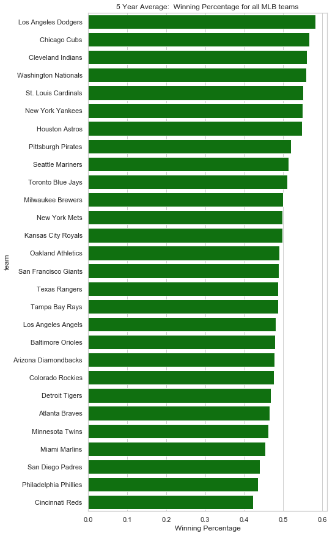

```python
sns.set(style="whitegrid")
plt.figure(figsize=(7,15))
ax = sns.barplot(x=mlb_5_1['WIN_PCT'], y=mlb_5_1['team'], color='green')
ax.set_title('5 Year Average:  Winning Percentage for all MLB teams')
ax.set_xlabel('Winning Percentage');
```

```python
def mlb_correlation():
    population_by_region = mlb_5_1.Population
    win_loss_by_region = mlb_5_1.WIN_PCT
    return stats.pearsonr(population_by_region, win_loss_by_region)

mlb_correlation()
```

```
(0.30321303434589525, 0.1167676005615437)
```

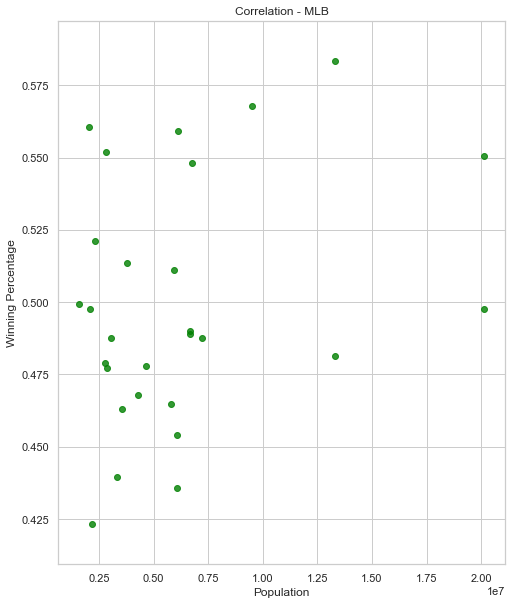

```python
#---  EXAMINING THE MLB DATA SCATTER PLOT  ---

plt.figure(figsize=(8,10))  # trying a different size now !
x = mlb_5_1.Population
y = mlb_5_1.WIN_PCT
plt.scatter(x, y, c='green', alpha=.8)
plt.title("Correlation - MLB")
plt.xlabel("Population")
plt.ylabel("Winning Percentage")
plt.show();
```

**Thoughts:** * As the population increases, there appears to be an increase in winning percentage (within reason) * .303 tells the story there is somewhat of a linear relationship...definitely something there...

```python
#<>
```

### - NHL:

```python
#  d4 is the previously created dictionary to map NBA teams to Metro Areas
```

```python
#---  f_nhl is the consolidated team and WIN_PCT for that nhl team
nhl2 = f_nhl.copy()
nhl2['Nickname'] = f_nhl['team'].apply(lambda x: x.split()[-1]).copy()
nhl2.replace({'Leafs': 'Maple Leafs','Jackets': 'Blue Jackets','Wings': 'Red Wings'}, inplace=True);

#---  MAP THE TEAM NICKNAME TO THE METRO AREA IT IS ASSOCIATED WITH  ---
nhl2['MSO'] = nhl2['Nickname'].map(d4)

#---  The Population value is now to be mapped appropriated (associated with correct METRO)
nhl2['Population'] = nhl2.MSO.map(metro_to_pop_DB)

nhl2.sort_values('Population', ascending=False, inplace=True)#  Show based on descending population
nhl2.reset_index(inplace=True, drop=True)#  resetting index

display(HTML(nhl2.head(30).to_html(index=False)))
```

| team | WIN_PCT | year | Nickname | MSO | Population |
| --- | --- | --- | --- | --- | --- |
| New York Islanders | 0.4789 | 2014 | Islanders | New York City | 20,153,634.0000 |
| New York Rangers | 0.7067 | 2015 | Rangers | New York City | 20,153,634.0000 |
| New York Islanders | 0.6267 | 2015 | Islanders | New York City | 20,153,634.0000 |
| New Jersey Devils | 0.4706 | 2015 | Devils | New York City | 20,153,634.0000 |
| New York Rangers | 0.4658 | 2018 | Rangers | New York City | 20,153,634.0000 |
| New York Islanders | 0.4861 | 2018 | Islanders | New York City | 20,153,634.0000 |
| New York Rangers | 0.6301 | 2016 | Rangers | New York City | 20,153,634.0000 |
| New Jersey Devils | 0.6027 | 2018 | Devils | New York City | 20,153,634.0000 |
| New York Islanders | 0.6250 | 2016 | Islanders | New York City | 20,153,634.0000 |
| New York Rangers | 0.6316 | 2017 | Rangers | New York City | 20,153,634.0000 |
| New Jersey Devils | 0.5135 | 2016 | Devils | New York City | 20,153,634.0000 |
| New York Islanders | 0.5857 | 2017 | Islanders | New York City | 20,153,634.0000 |
| New Jersey Devils | 0.5469 | 2014 | Devils | New York City | 20,153,634.0000 |
| New York Rangers | 0.5921 | 2014 | Rangers | New York City | 20,153,634.0000 |
| New Jersey Devils | 0.4118 | 2017 | Devils | New York City | 20,153,634.0000 |
| Anaheim Ducks | 0.6800 | 2015 | Ducks | Los Angeles | 13,310,447.0000 |
| Los Angeles Kings | 0.5970 | 2015 | Kings | Los Angeles | 13,310,447.0000 |
| Los Angeles Kings | 0.5270 | 2017 | Kings | Los Angeles | 13,310,447.0000 |
| Anaheim Ducks | 0.6377 | 2018 | Ducks | Los Angeles | 13,310,447.0000 |
| Anaheim Ducks | 0.6667 | 2017 | Ducks | Los Angeles | 13,310,447.0000 |
| Anaheim Ducks | 0.7297 | 2014 | Ducks | Los Angeles | 13,310,447.0000 |
| Los Angeles Kings | 0.6216 | 2014 | Kings | Los Angeles | 13,310,447.0000 |
| Anaheim Ducks | 0.6479 | 2016 | Ducks | Los Angeles | 13,310,447.0000 |
| Los Angeles Kings | 0.6316 | 2016 | Kings | Los Angeles | 13,310,447.0000 |
| Los Angeles Kings | 0.6081 | 2018 | Kings | Los Angeles | 13,310,447.0000 |
| Chicago Blackhawks | 0.6866 | 2014 | Blackhawks | Chicago | 9,512,999.0000 |
| Chicago Blackhawks | 0.6849 | 2017 | Blackhawks | Chicago | 9,512,999.0000 |
| Chicago Blackhawks | 0.6316 | 2015 | Blackhawks | Chicago | 9,512,999.0000 |
| Chicago Blackhawks | 0.4583 | 2018 | Blackhawks | Chicago | 9,512,999.0000 |
| Chicago Blackhawks | 0.6438 | 2016 | Blackhawks | Chicago | 9,512,999.0000 |

```python
print("\nThe following contains the overall winning percentage (in descending order)\nover the course of five years, for all NHL teams:")
nhl_5 = nhl2

nhl_5_1 = nhl_5.groupby(['team','MSO','Population'], as_index=False).WIN_PCT.mean()

#.agg({'WIN_PCT':'mean'})
#nfl_5_1= nfl_5.groupby('team', as_index=False)#['WIN_PCT'].mean() #  .WIN_PCT.mean()
# nfl_5_1 = nfl_5_1.sort_values('WIN_PCT', ascending=False)
# nfl_5_1.reset_index(inplace=True, drop=True)
nhl_5_1 = nhl_5_1.sort_values('WIN_PCT', ascending=False)
#sh(nfl_5_1)
display(HTML(nhl_5_1.to_html(index=False)))
```

```
The following contains the overall winning percentage (in descending order)
over the course of five years, for all NHL teams:
```

| team | MSO | Population | WIN_PCT |
| --- | --- | --- | --- |
| Anaheim Ducks | Los Angeles | 13,310,447.0000 | 0.6724 |
| Washington Capitals | Washington, D.C. | 6,131,977.0000 | 0.6692 |
| Pittsburgh Penguins | Pittsburgh | 2,342,299.0000 | 0.6531 |
| St. Louis Blues | St. Louis | 2,807,002.0000 | 0.6474 |
| Boston Bruins | Boston | 4,794,447.0000 | 0.6438 |
| Tampa Bay Lightning | Tampa Bay Area | 3,032,171.0000 | 0.6376 |
| Nashville Predators | Nashville | 1,865,298.0000 | 0.6262 |
| Chicago Blackhawks | Chicago | 9,512,999.0000 | 0.6210 |
| San Jose Sharks | San Francisco Bay Area | 6,657,982.0000 | 0.6180 |
| Minnesota Wild | Minneapolis–Saint Paul | 3,551,036.0000 | 0.6134 |
| New York Rangers | New York City | 20,153,634.0000 | 0.6052 |
| Los Angeles Kings | Los Angeles | 13,310,447.0000 | 0.5971 |
| Montreal Canadiens | Montreal | 4,098,927.0000 | 0.5760 |
| Winnipeg Jets | Winnipeg | 778,489.0000 | 0.5731 |
| Dallas Stars | Dallas–Fort Worth | 7,233,323.0000 | 0.5728 |
| Philadelphia Flyers | Philadelphia | 6,070,500.0000 | 0.5722 |
| Columbus Blue Jackets | Columbus | 2,041,520.0000 | 0.5708 |
| New York Islanders | New York City | 20,153,634.0000 | 0.5605 |
| Phoenix Coyotes | Phoenix | 4,661,537.0000 | 0.5522 |
| Detroit Red Wings | Detroit | 4,297,617.0000 | 0.5410 |
| Ottawa Senators | Ottawa | 1,323,783.0000 | 0.5387 |
| Florida Panthers | Miami–Fort Lauderdale | 6,066,387.0000 | 0.5381 |
| Colorado Avalanche | Denver | 2,853,077.0000 | 0.5262 |
| Calgary Flames | Calgary | 1,392,609.0000 | 0.5248 |
| Toronto Maple Leafs | Toronto | 5,928,040.0000 | 0.5155 |
| New Jersey Devils | New York City | 20,153,634.0000 | 0.5091 |
| Carolina Hurricanes | Raleigh | 1,302,946.0000 | 0.5008 |
| Vancouver Canucks | Vancouver | 2,463,431.0000 | 0.4855 |
| Edmonton Oilers | Edmonton | 1,321,426.0000 | 0.4573 |
| Arizona Coyotes | Phoenix | 4,661,537.0000 | 0.4071 |
| Buffalo Sabres | Buffalo | 1,132,804.0000 | 0.3848 |

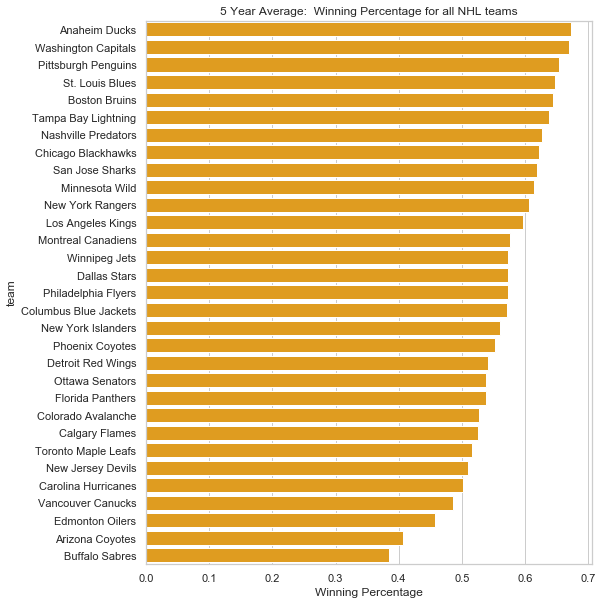

```python
sns.set(style="whitegrid")
plt.figure(figsize=(8,10))

ax = sns.barplot(x=nhl_5_1['WIN_PCT'], y=nhl_5_1['team'], color='orange')
ax.set_title('5 Year Average:  Winning Percentage for all NHL teams')
ax.set_xlabel('Winning Percentage');
```

```python
def nhl_correlation():
    population_by_region = nhl_5_1.Population
    win_loss_by_region = nhl_5_1.WIN_PCT
    return stats.pearsonr(population_by_region, win_loss_by_region)

nhl_correlation()
```

```
(0.18888326924416657, 0.3088500924784735)
```

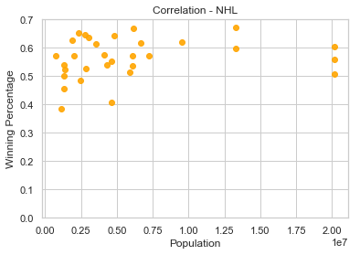

```python
#---  EXAMINING THE MLB DATA SCATTER PLOT  ---

x = nhl_5_1.Population
y = nhl_5_1.WIN_PCT
plt.scatter(x, y, c='orange', alpha=.9)
plt.title("Correlation - NHL")
plt.xlabel("Population")
plt.ylabel("Winning Percentage")
plt.ylim(0)
plt.show();
```

**Thoughts:** * .189 shows somewhat of a linear relationship, but not much...